# Data Analysis I

## Data Analysis Task 1

Data scientists spend a large amount of their time cleaning datasets and getting them down to a form with which they can work. In fact, a lot of data scientists argue that the initial steps of obtaining and cleaning data constitute 80% of the job. It is important to be able to deal with messy data, whether that means missing values, inconsistent formatting, malformed records, or nonsensical outliers.

```python
import pandas as pd
import numpy as np

df = pd.read_table("balance.txt", delim_whitespace=True)
df.head(5)
```

|  | Balance | Income | Limit | Rating | Cards | Age | Education | Gender | Student | Married | Ethnicity |
| --- | --- | --- | --- | --- | --- | --- | --- | --- | --- | --- | --- |
| 0 | 12.2407984760474 | 14.891 | 3606 | 283.0 | 2.0 | NaN | 11.0 | Male | No | Yes | Caucasian |
| 1 | 23.2833339223376 | NaN | 6645 | 483.0 | 3.0 | 82.0 | 15.0 | Female | NaN | Yes | Asian |
| 2 | 22.5304088790893 | 104.593 | 7075 | NaN | 4.0 | 71.0 | 11.0 | Male | No | No | Asian |
| 3 | 27.652810710665 | 148.924 | 9504 | 681.0 | 3.0 | 36.0 | 11.0 | NaN | No | No | Asian |
| 4 | 16.8939784904888 | 55.882 | 4897 | 357.0 | 2.0 | 68.0 | 16.0 | Male | No | Yes | Caucasian |

### Dropping Columns in a DataFrame

Often, you’ll find that not all the categories of data in a dataset are useful to you. For example, you might have a dataset containing student information (name, grade, standard, parents’ names, and address) but want to focus on analyzing student grades. In this case, the address or parents’ names categories are not important to you. Retaining these unneeded categories will take up unnecessary space and potentially also bog down runtime.

Pandas provides a handy way of removing unwanted columns or rows from a DataFramewith the drop() function. Let’s look at a simple example where we drop a number of columns from a DataFrame.

```python
df.drop(['Limit','Age'],inplace=True, axis=1)
```

Above, we defined a list that contains the names of all the columns we want to drop. Next, we call the drop() function on our object, passing in the inplace parameter as True and the axis parameter as 1. This tells Pandas that we want the changes to be made directly in our object and that it should look for the values to be dropped in the columns of the object.

When we inspect the DataFrame again, we’ll see that the unwanted columns have been removed.

```python
df.head()
```

|  | Balance | Income | Rating | Cards | Education | Gender | Student | Married | Ethnicity |
| --- | --- | --- | --- | --- | --- | --- | --- | --- | --- |
| 0 | 12.2407984760474 | 14.891 | 283.0 | 2.0 | 11.0 | Male | No | Yes | Caucasian |
| 1 | 23.2833339223376 | NaN | 483.0 | 3.0 | 15.0 | Female | NaN | Yes | Asian |
| 2 | 22.5304088790893 | 104.593 | NaN | 4.0 | 11.0 | Male | No | No | Asian |
| 3 | 27.652810710665 | 148.924 | 681.0 | 3.0 | 11.0 | NaN | No | No | Asian |
| 4 | 16.8939784904888 | 55.882 | 357.0 | 2.0 | 16.0 | Male | No | Yes | Caucasian |

### Replace values

Sometimes you would like to replace a value from your data set with another value. For example if you had data with categories such as ‘Ethnicity’ and we wanted to rename one category lets say, 'African American' to 'African'.

```python
df.replace('African American','African').head(10)
```

|  | Balance | Income | Rating | Cards | Education | Gender | Student | Married | Ethnicity |
| --- | --- | --- | --- | --- | --- | --- | --- | --- | --- |
| 0 | 12.2407984760474 | 14.891 | 283.0 | 2.0 | 11.0 | Male | No | Yes | Caucasian |
| 1 | 23.2833339223376 | NaN | 483.0 | 3.0 | 15.0 | Female | NaN | Yes | Asian |
| 2 | 22.5304088790893 | 104.593 | NaN | 4.0 | 11.0 | Male | No | No | Asian |
| 3 | 27.652810710665 | 148.924 | 681.0 | 3.0 | 11.0 | NaN | No | No | Asian |
| 4 | 16.8939784904888 | 55.882 | 357.0 | 2.0 | 16.0 | Male | No | Yes | Caucasian |
| 5 | 22.4861776123913 | 80.18 | 569.0 | 4.0 | 10.0 | Male | No | No | Caucasian |
| 6 | 10.5745164367595 | 20.996 | 259.0 | 2.0 | 12.0 | Female | No | No | African |
| 7 | 14.5762043512884 | 71.408 | 512.0 | 2.0 | 9.0 | Male | No | No | Asian |
| 8 | 7.93809029500252 | 15.125 | 266.0 | 5.0 | 13.0 | Female | No | No | Caucasian |
| 9 | 17.7569648697007 | 71.061 | 491.0 | 3.0 | 19.0 | Female | Yes | Yes | African |

### Grouping Data

Grouping data sets is a frequent need in data analysis where we need the result in terms of various groups present in the data set. Panadas has in-built methods which can roll the data into various groups.

In the below example we group the data by Ethnicity and then get the result for a specific Ethnic group.

```python
grouped = df.groupby('Ethnicity')
grouped.get_group('Asian').head()
```

|  | Balance | Income | Rating | Cards | Education | Gender | Student | Married | Ethnicity |
| --- | --- | --- | --- | --- | --- | --- | --- | --- | --- |
| 1 | 23.2833339223376 | NaN | 483.0 | 3.0 | 15.0 | Female | NaN | Yes | Asian |
| 2 | 22.5304088790893 | 104.593 | NaN | 4.0 | 11.0 | Male | No | No | Asian |
| 3 | 27.652810710665 | 148.924 | 681.0 | 3.0 | 11.0 | NaN | No | No | Asian |
| 7 | 14.5762043512884 | 71.408 | 512.0 | 2.0 | 9.0 | Male | No | No | Asian |
| 12 | 19.2188003192702 | 80.616 | 394.0 | 1.0 | 7.0 | Female | No | Yes | Asian |

### Dealing with inconsistent data entry

To begin with, let us install a module that will help us clean our data set. Go to your command prompt and type `pip3 install fuzzywuzzy`

```python
# helpful modules
import fuzzywuzzy
from fuzzywuzzy import process
import chardet

# set seed for reproducibility
np.random.seed(0)
```

```python
suicide_attacks = pd.read_csv(r"C:\Users\byamu\Dropbox\Tony Byamungu-28775\Data Analytics and Exploration\Task 13\Pakistan.csv"
                              ,encoding = 'unicode_escape'
)
suicide_attacks['City'].tail()
```

```
491      Quetta
492      Quetta
493      Quetta
494    Peshawar
495      Quetta
Name: City, dtype: object
```

#### Text pre-processing

For this exercise, we are interested in cleaning up the "City" column to make sure there's no data entry inconsistencies in it. We could go through and check each row by hand, of course, and hand-correct inconsistencies when we find them. There's a more efficient way to do this though!

```python
cities = suicide_attacks['City'].unique()
# sort them alphabetically and then take a closer look
cities.sort()
cities
```

```
array(['ATTOCK', 'Attock ', 'Bajaur Agency', 'Bannu', 'Bhakkar ', 'Buner',
       'Chakwal ', 'Chaman', 'Charsadda', 'Charsadda ', 'D. I Khan',
       'D.G Khan', 'D.G Khan ', 'D.I Khan', 'D.I Khan ', 'Dara Adam Khel',
       'Dara Adam khel', 'Fateh Jang', 'Ghallanai, Mohmand Agency ',
       'Gujrat', 'Hangu', 'Haripur', 'Hayatabad', 'Islamabad',
       'Islamabad ', 'Jacobabad', 'KURRAM AGENCY', 'Karachi', 'Karachi ',
       'Karak', 'Khanewal', 'Khuzdar', 'Khyber Agency', 'Khyber Agency ',
       'Kohat', 'Kohat ', 'Kuram Agency ', 'Lahore', 'Lahore ',
       'Lakki Marwat', 'Lakki marwat', 'Lasbela', 'Lower Dir', 'MULTAN',
       'Malakand ', 'Mansehra', 'Mardan', 'Mohmand Agency',
       'Mohmand Agency ', 'Mohmand agency', 'Mosal Kor, Mohmand Agency',
       'Multan', 'Muzaffarabad', 'North Waziristan', 'North waziristan',
       'Nowshehra', 'Orakzai Agency', 'Peshawar', 'Peshawar ', 'Pishin',
       'Poonch', 'Quetta', 'Quetta ', 'Rawalpindi', 'Sargodha',
       'Sehwan town', 'Shabqadar-Charsadda', 'Shangla ', 'Shikarpur',
       'Sialkot', 'South Waziristan', 'South waziristan', 'Sudhanoti',
       'Sukkur', 'Swabi ', 'Swat', 'Swat ', 'Taftan',
       'Tangi, Charsadda District', 'Tank', 'Tank ', 'Taunsa',
       'Tirah Valley', 'Totalai', 'Upper Dir', 'Wagah', 'Zhob', 'bannu',
       'karachi', 'karachi ', 'lakki marwat', 'peshawar', 'swat'],
      dtype=object)
```

Just looking at this, I can see some problems due to inconsistent data entry. Let us look at the first entry 'ATTOCK' and 'Attock'. These are the same cities but the computer understands then as different.

The first thing we need to do is make everything lower case (We can change it back at the end if we'd like) and remove any white spaces at the beginning and end of cells. Inconsistencies in capitalizations and trailing white spaces are very common in text data and you can fix a good 80% of your text data entry inconsistencies by doing this.

```python
# convert to lower case
suicide_attacks['City'] = suicide_attacks['City'].str.lower()

# remove trailing white spaces
suicide_attacks['City'] = suicide_attacks['City'].str.strip()

# Let us view the data

cities = suicide_attacks['City'].unique()
# sort them alphabetically and then take a closer look
cities.sort()
cities
```

```
array(['attock', 'bajaur agency', 'bannu', 'bhakkar', 'buner', 'chakwal',
       'chaman', 'charsadda', 'd. i khan', 'd.g khan', 'd.i khan',
       'dara adam khel', 'fateh jang', 'ghallanai, mohmand agency',
       'gujrat', 'hangu', 'haripur', 'hayatabad', 'islamabad',
       'jacobabad', 'karachi', 'karak', 'khanewal', 'khuzdar',
       'khyber agency', 'kohat', 'kuram agency', 'kurram agency',
       'lahore', 'lakki marwat', 'lasbela', 'lower dir', 'malakand',
       'mansehra', 'mardan', 'mohmand agency',
       'mosal kor, mohmand agency', 'multan', 'muzaffarabad',
       'north waziristan', 'nowshehra', 'orakzai agency', 'peshawar',
       'pishin', 'poonch', 'quetta', 'rawalpindi', 'sargodha',
       'sehwan town', 'shabqadar-charsadda', 'shangla', 'shikarpur',
       'sialkot', 'south waziristan', 'sudhanoti', 'sukkur', 'swabi',
       'swat', 'taftan', 'tangi, charsadda district', 'tank', 'taunsa',
       'tirah valley', 'totalai', 'upper dir', 'wagah', 'zhob'],
      dtype=object)
```

Alright, let's take another look at the city column and see if there's any more data cleaning we need to do.

It does look like there are some remaining inconsistencies: 'd. i khan' and 'd.i khan' should probably be the same.

We are going to use the fuzzywuzzy package to help identify which string are closest to each other. This dataset is small enough that we could probably could correct errors by hand, but that approach doesn't scale well. (Would you want to correct a thousand errors by hand? What about ten thousand? Automating things as early as possible is generally a good idea. Plus, it’s fun! :)

Fuzzy matching: The process of automatically finding text strings that are very similar to the target string. In general, a string is considered "closer" to another one the fewer characters you'd need to change if you were transforming one string into another. So "apple" and "snapple" are two changes away from each other (add "s" and "n") while "in" and "on" and one change away (rplace "i" with "o"). You won't always be able to rely on fuzzy matching 100%, but it will usually end up saving you at least a little time.

Fuzzywuzzy returns a ratio given two strings. The closer the ratio is to 100, the smaller the edit distance between the two strings. Here, we're going to get the ten strings from our list of cities that have the closest distance to "d.i khan".

```python
# get the top 10 closest matches to "d.i khan"
matches = fuzzywuzzy.process.extract("d.i khan", cities, limit=10, scorer=fuzzywuzzy.fuzz.token_sort_ratio)

# take a look at them
matches
```

```
[('d. i khan', 100),
 ('d.i khan', 100),
 ('d.g khan', 88),
 ('khanewal', 50),
 ('sudhanoti', 47),
 ('hangu', 46),
 ('kohat', 46),
 ('dara adam khel', 45),
 ('chaman', 43),
 ('mardan', 43)]
```

To do this, we going to write a function. (It's a good idea to write a general purpose function you can reuse if you think you might have to do a specific task more than once or twice. This keeps you from having to copy and paste code too often, which saves time and can help prevent mistakes.)

```python
# function to replace rows in the provided column of the provided dataframe
# that match the provided string above the provided ratio with the provided string
def replace_matches_in_column(df, column, string_to_match, min_ratio = 90):

    # get a list of unique strings
    strings = df[column].unique()

    # get the top 10 closest matches to our input string
    matches = fuzzywuzzy.process.extract(string_to_match, strings,
                                         limit=10, scorer=fuzzywuzzy.fuzz.token_sort_ratio)

    # only get matches with a ratio > 90
    close_matches = [matches[0] for matches in matches if matches[1] >= min_ratio]

    # get the rows of all the close matches in our dataframe
    rows_with_matches = df[column].isin(close_matches)

    # replace all rows with close matches with the input matches
    df.loc[rows_with_matches, column] = string_to_match

    # let us know the function's done
```

Now that we have a function, we can put it to the test!

```python
# use the function we just wrote to replace close matches to
# "d.i khan" with "d.i khan"
replace_matches_in_column(df=suicide_attacks, column='City', string_to_match="d.i khan")
```

And now let's can check the unique values in our City column again and make sure we've tidied up d.i khan correctly.

```python
# get all the unique values in the 'City' column
cities = suicide_attacks['City'].unique()

# sort them alphabetically and then take a closer look
cities.sort()
cities
```

```
array(['attock', 'bajaur agency', 'bannu', 'bhakkar', 'buner', 'chakwal',
       'chaman', 'charsadda', 'd.g khan', 'd.i khan', 'dara adam khel',
       'fateh jang', 'ghallanai, mohmand agency', 'gujrat', 'hangu',
       'haripur', 'hayatabad', 'islamabad', 'jacobabad', 'karachi',
       'karak', 'khanewal', 'khuzdar', 'khyber agency', 'kohat',
       'kuram agency', 'kurram agency', 'lahore', 'lakki marwat',
       'lasbela', 'lower dir', 'malakand', 'mansehra', 'mardan',
       'mohmand agency', 'mosal kor, mohmand agency', 'multan',
       'muzaffarabad', 'north waziristan', 'nowshehra', 'orakzai agency',
       'peshawar', 'pishin', 'poonch', 'quetta', 'rawalpindi', 'sargodha',
       'sehwan town', 'shabqadar-charsadda', 'shangla', 'shikarpur',
       'sialkot', 'south waziristan', 'sudhanoti', 'sukkur', 'swabi',
       'swat', 'taftan', 'tangi, charsadda district', 'tank', 'taunsa',
       'tirah valley', 'totalai', 'upper dir', 'wagah', 'zhob'],
      dtype=object)
```

### Working with Data and time

Analyzing datasets with dates and times is often very cumbersome. Months of different lengths, different distributions of weekdays and weekends, leap years, and the dreaded timezones are just a few things you may have to consider depending on your context. For this reason, Python has a data type specifically designed for dates and times called datetime.

```python
# modules we'll use
#import seaborn as sns
from datetime import date
# print the first few rows of the date column
print(suicide_attacks['Date'].head())
```

```
0    November 19-1995
1     November 6-2000
2          May 8-2002
3        June 14-2002
4         July 4-2003
Name: Date, dtype: object
```

Yep, those are dates! But just because we can understand that it doesnt meant that the computer understands them as so. Notice that the at the bottom of the output of head(), you can see that it says that the data type of this column is "object".

Pandas uses the "object" dtype for storing various types of data types, but most often when you see a column with the dtype "object" it will have strings in it.

If you check the pandas dtype documentation here, you'll notice that there's also a specific datetime64 dtypes. Because the dtype of our column is object rather than datetime64, we can tell that Python doesn't know that this column contains dates.

We can also look at just the dtype of your column without printing the first few rows if we like:

```python
# check the data type of our date column
suicide_attacks['Date'].dtype
```

```
dtype('O')
```

You may have to check the numpy documentation to match the letter code to the dtype of the object. "O" is the code for "object", so we can see that these two methods give us the same information.

### Convert our date columns to datetime

Now that we know that our date column isn't being recognized as a date, it's time to convert it so that it is recognized as a date. This is called "parsing dates" because we're taking in a string and identifying its component parts.

We can pandas what the format of our dates are with a guide called as "strftime directive", which you can find more information on at this link. The basic idea is that you need to point out which parts of the date are where and what punctuation is between them. There are lots of possible parts of a date,

| Code | Meaning | Example |
| --- | --- | --- |
| %A | Weekday as locale’s full name | Wednesday |
| %a | Weekday as locale’s abbreviated name | Wed |
| %B | Month as locale’s full name | June |
| %d | Day of the month | 06 |
| %m | Month as a number | 6 |
| %Y | Four-digit year | 2018 |
| %y | Two-digit year | 18 |

Some examples:

1/17/07 has the format "%m/%d/%y"

17-1-2007 has the format "%d-%m-%Y"

```python
# create a new column, date_parsed, with the parsed dates


suicide_attacks['date_parsed'] = pd.to_datetime(suicide_attacks['Date'], format='%B %d-%Y')


suicide_attacks['date_parsed'].head()
```

```
0   1995-11-19
1   2000-11-06
2   2002-05-08
3   2002-06-14
4   2003-07-04
Name: date_parsed, dtype: datetime64[ns]
```

Now when I check the first few rows of the new column, I can see that the dtype is datetime64. I can also see that my dates have been slightly rearranged so that they fit the default order datetime objects (year-month-day).

Now that our dates are parsed correctly, we can interact with them in useful ways.

What if I run into an error with multiple date formats? While we're specifying the date format here, sometimes you'll run into an error when there are multiple date formats in a single column. If that happens, you have have pandas try to infer what the right date format should be. You can do that like so:

landslides['date_parsed'] = pd.to_datetime(landslides['Date'], infer_datetime_format=True)

Why don't you always use infer_datetime_format = True? There are two big reasons not to always have pandas guess the time format. The first is that pandas won't always been able to figure out the correct date format, especially if someone has gotten creative with data entry. The second is that it's much slower than specifying the exact format of the dates.

# Compulsory Tasks

```python
# Take a look at all the unique values in the "Province" column.
# Then convert the column to lowercase and remove any trailing white spaces

suicide_attacks['Province'].unique
```

```
<bound method Series.unique of 0          Capital
1            Sindh
2            Sindh
3            Sindh
4      Baluchistan
5           Punjab
6           Punjab
7            Sindh
8            Sindh
9             FATA
10             KPK
11          Punjab
12          Punjab
13          Punjab
14     Baluchistan
```

[output cut: 47 more lines]

```python
suicide_attacks['Province'].isnull().sum()#over here we're checking if there's any missing value in this column
```

```
0
```

as we can see there's some bias in this comlumn like FATA and Fata, though we have inconsistant data entry, thanks God we do not have missing value or null

```python
## now we gonna go ahead and remove those bias
suicide_attacks['Province'] = suicide_attacks['Province'].str.lower().str.strip()
```

### It looks like 'kuram agency' and 'kurram agency' should

### be the same city. Correct the dataframe so that they are.

```python
#remember we have created a function up there? I know you can remember that.
#it's not cheating its taking advantage of tools (lol)

replace_matches_in_column(suicide_attacks, 'City', 'kuram agency' )
suicide_attacks['City'].unique()
```

```
array(['islamabad', 'karachi', 'quetta', 'rawalpindi', 'north waziristan',
       'kohat', 'attock', 'sialkot', 'lahore', 'swat', 'hangu', 'bannu',
       'lasbela', 'malakand', 'peshawar', 'd.i khan', 'lakki marwat',
       'tank', 'gujrat', 'charsadda', 'kuram agency', 'shangla',
       'bajaur agency', 'south waziristan', 'haripur', 'sargodha',
       'nowshehra', 'mohmand agency', 'dara adam khel', 'khyber agency',
       'mardan', 'bhakkar', 'orakzai agency', 'buner', 'd.g khan',
       'pishin', 'chakwal', 'upper dir', 'muzaffarabad', 'totalai',
       'multan', 'lower dir', 'sudhanoti', 'poonch', 'mansehra', 'karak',
       'swabi', 'shikarpur', 'sukkur', 'chaman', 'khanewal', 'fateh jang',
       'taftan', 'tirah valley', 'wagah', 'zhob', 'taunsa', 'jacobabad',
       'shabqadar-charsadda', 'khuzdar', 'ghallanai, mohmand agency',
       'hayatabad', 'mosal kor, mohmand agency', 'sehwan town',
       'tangi, charsadda district'], dtype=object)
```

### PakistanTask.csv file from this dataset and tidying up any

### inconsistent columns [city & Province] in that data file.

```python
pakistan = pd.read_csv(r"C:\Users\byamu\Dropbox\Tony Byamungu-28775\Data Analytics and Exploration\Task 13\PakistanTask.csv",
                      encoding = 'unicode_escape')

pakistan.head()
```

|  | S# | Date | Islamic Date | Blast Day Type | Holiday Type | Time | City | Latitude | Longitude | Province | ... | Targeted Sect if any | Killed Min | Killed Max | Injured Min | Injured Max | No. of Suicide Blasts | Explosive Weight (max) | Hospital Names | Temperature(C) | Temperature(F) |
| --- | --- | --- | --- | --- | --- | --- | --- | --- | --- | --- | --- | --- | --- | --- | --- | --- | --- | --- | --- | --- | --- |
| 0 | 1.0 | Sunday-November 19-1995 | 25 Jumaada al-THaany 1416 A.H | Holiday | Weekend | NaN | Islamabad | 33.7180 | 73.0718 | Capital | ... | None | 14.0 | 15.0 | NaN | 60.0 | 2.0 | NaN | NaN | 15.835 | 60.503 |
| 1 | 2.0 | Monday-November 6-2000 | 10 SHa`baan 1421 A.H | Working Day | NaN | NaN | Karachi | 24.9918 | 66.9911 | Sindh | ... | None | NaN | 3.0 | NaN | 3.0 | 1.0 | NaN | NaN | 23.770 | 74.786 |
| 2 | 3.0 | Wednesday-May 8-2002 | 25 safar 1423 A.H | Working Day | NaN | 7:45 AM | Karachi | 24.9918 | 66.9911 | Sindh | ... | Christian | 13.0 | 15.0 | 20.0 | 40.0 | 1.0 | 2.5 Kg | 1.Jinnah Postgraduate Medical Center 2. Civil ... | 31.460 | 88.628 |
| 3 | 4.0 | Friday-June 14-2002 | 3 Raby` al-THaany 1423 A.H | Working Day | NaN | 11:10:00 AM | Karachi | 24.9918 | 66.9911 | Sindh | ... | Christian | NaN | 12.0 | NaN | 51.0 | 1.0 | NaN | NaN | 31.430 | 88.574 |
| 4 | 5.0 | Friday-July 4-2003 | 4 Jumaada al-awal 1424 A.H | Working Day | NaN | NaN | Quetta | 30.2095 | 67.0182 | Baluchistan | ... | Shiite | 44.0 | 47.0 | NaN | 65.0 | 1.0 | NaN | 1.CMH Quetta \n2.Civil Hospital 3. Boland Medi... | 33.120 | 91.616 |

5 rows × 26 columns

```python
pakistan.isnull().sum()
```

```
S#                          38
Date                        38
Islamic Date               172
Blast Day Type              48
Holiday Type               414
Time                       221
City                        38
Latitude                    38
Longitude                   38
Province                    38
Location                    41
Location Category           52
Location Sensitivity        55
Open/Closed Space           54
Influencing Event/Event    330
Target Type                 51
Targeted Sect if any        71
Killed Min                 183
Killed Max                  52
Injured Min                163
Injured Max                 65
No. of Suicide Blasts      104
Explosive Weight (max)     328
Hospital Names             211
Temperature(C)              39
Temperature(F)              39
dtype: int64
```

WE HAVE SOME BAD NEWS!!! ALL OUR COLUMNS HAVE MISSING VALUES

```python
#so if we call the unique method on one of the columns we gonna get a extra unique value called NaN
#putting that fact in mind, is going to affect how we clean our data and the  decision we make
pakistan.Province.unique()
```

```
array(['Capital', 'Sindh', 'Baluchistan', 'Punjab', 'FATA', 'KPK', 'AJK',
       'Fata', 'Balochistan', nan], dtype=object)
```

```python
#so we call all null rows or city that have name nan and sum them up

pakistan['City'].isnull().sum()
```

```
38
```

OooPs it looks like we have 38 cities called nan!that is not good.

#### Just because we can, let's automate the boring stuff.

we gonna go ahead and create a function that will lower the values and remove the trailing white spaces, then we're going to create another function that will clean data inconsistancy by using the replace_matches_in_column function created above and our new function. OK so let's jump straight into it and have fun with the 'City' & 'Province'

```python
#over here we create a funtion that will lower and remove the trailing white spaces

def lower_and_remove_space(df, column):

    '''this function takes in a dataframe and a column as argument,
    then lowers all the values of that columns and remove any trailing white spaces'''

    df[column] = df[column].str.lower().str.strip()

    print('\a')
```

```python
def clean_data_inconsistency(df, column):

    '''This Function takes in a dataframe and a column(columnn as a string)
    then lower the values of the column, removes any trailling white spaces
    and replace all mathes or values that look similar.

    NB: the similarity is set to 90 percent
        and the function is set to select only rows that has positive
        values.


    '''


    #over here we take we pass the df and column in a subfunction that lowers
    #and removes trailing white spaces
    lower_and_remove_space(df, column)

    #over here we look through the notnull rows of the column provided.(does that make any sense?)
    #why we're doing this? we're looking for the string to match. so the iterator is going in the df and picks a name
    #and pass it in the subfuction below.
    for string_to_match in df[df[column].notnull()][column]:

        replace_matches_in_column(df, column, string_to_match) #i think the variable names can tell the story.

    print('All Clean')
```

before we decide what we going to do with those missing values, let's first clean up the province and City columns first maybe it can help our decision... because (the last time I check) there was a good relationship between province and city.

```python
clean_data_inconsistency(pakistan, "Province")
pakistan.Province.unique()
```

```
All Clean
```

```
array(['kpk', 'punjab', 'fata', 'balochistan', 'ajk', 'capital', 'sindh'],
      dtype=object)
```

```python
clean_data_inconsistency(pakistan, "City")
pakistan['City'].sort_values().unique()
```

```
All Clean
```

```
array(['attock', 'bajaur agency', 'bannu', 'bhakkar', 'buner', 'chakwal',
       'chaman', 'charsadda', 'd. i khan', 'd.g khan', 'dara adam khel',
       'fateh jang', 'gujrat', 'hangu', 'haripur', 'islamabad', 'karachi',
       'karak', 'khanewal', 'khyber agency', 'kohat', 'kurram agency',
       'lahore', 'lakki marwat', 'lasbela', 'lower dir', 'malakand',
       'mansehra', 'mardan', 'mohmand agency', 'multan', 'muzaffarabad',
       'north waziristan', 'nowshehra', 'orakzai agency', 'peshawar',
       'pishin', 'poonch', 'quetta', 'rawalpindi', 'sargodha', 'shangla',
       'shikarpur', 'sialkot', 'south waziristan', 'sudhanoti', 'sukkur',
       'swabi', 'swat', 'taftan', 'tank', 'tirah valley', 'totalai',
       'upper dir', 'wagah', 'zhob'], dtype=object)
```

```python
pakistan['City'].sort_values().unique()
```

```
array(['attock', 'bajaur agency', 'bannu', 'bhakkar', 'buner', 'chakwal',
       'chaman', 'charsadda', 'd. i khan', 'd.g khan', 'dara adam khel',
       'fateh jang', 'gujrat', 'hangu', 'haripur', 'islamabad', 'karachi',
       'karak', 'khanewal', 'khyber agency', 'kohat', 'kurram agency',
       'lahore', 'lakki marwat', 'lasbela', 'lower dir', 'malakand',
       'mansehra', 'mardan', 'mohmand agency', 'multan', 'muzaffarabad',
       'north waziristan', 'nowshehra', 'orakzai agency', 'peshawar',
       'pishin', 'poonch', 'quetta', 'rawalpindi', 'sargodha', 'shangla',
       'shikarpur', 'sialkot', 'south waziristan', 'sudhanoti', 'sukkur',
       'swabi', 'swat', 'taftan', 'tank', 'tirah valley', 'totalai',
       'upper dir', 'wagah', 'zhob'], dtype=object)
```

```python
pakistan.columns
```

```
Index(['S#', 'Date', 'Islamic Date', 'Blast Day Type', 'Holiday Type', 'Time',
       'City', 'Latitude', 'Longitude', 'Province', 'Location',
       'Location Category', 'Location Sensitivity', 'Open/Closed Space',
       'Influencing Event/Event', 'Target Type', 'Targeted Sect if any',
       'Killed Min', 'Killed Max', 'Injured Min', 'Injured Max',
       'No. of Suicide Blasts', 'Explosive Weight (max)', 'Hospital Names',
       'Temperature(C)', 'Temperature(F)'],
      dtype='object')
```

```python
##looking at the output below we see that we have quiet a great deal of missing vallues
##does our task include dealing with those missing values?
##let's find out!
pakistan.isnull().sum()
```

```
S#                          38
Date                        38
Islamic Date               172
Blast Day Type              48
Holiday Type               414
Time                       221
City                        38
Latitude                    38
Longitude                   38
Province                    38
Location                    41
Location Category           52
Location Sensitivity        55
Open/Closed Space           54
Influencing Event/Event    330
Target Type                 51
Targeted Sect if any        71
Killed Min                 183
Killed Max                  52
Injured Min                163
Injured Max                 65
No. of Suicide Blasts      104
Explosive Weight (max)     328
Hospital Names             211
Temperature(C)              39
Temperature(F)              39
dtype: int64
```

### Create a new column, date_parsed, in the PakistanTask.csv

### dataset that has correctly parsed dates in it. (Don't forget to

### double-check that the dtype is correct!)

```python
pakistan['date_parsed'] = pd.to_datetime(pakistan['Date'])

#pakistan.groupby(pakistan['date_parsed'].dt.weekday_name)
pakistan.head(3)
```

|  | S# | Date | Islamic Date | Blast Day Type | Holiday Type | Time | City | Latitude | Longitude | Province | ... | Killed Min | Killed Max | Injured Min | Injured Max | No. of Suicide Blasts | Explosive Weight (max) | Hospital Names | Temperature(C) | Temperature(F) | date_parsed |
| --- | --- | --- | --- | --- | --- | --- | --- | --- | --- | --- | --- | --- | --- | --- | --- | --- | --- | --- | --- | --- | --- |
| 0 | 1.0 | Sunday-November 19-1995 | 25 Jumaada al-THaany 1416 A.H | Holiday | Weekend | NaN | islamabad | 33.7180 | 73.0718 | capital | ... | 14.0 | 15.0 | NaN | 60.0 | 2.0 | NaN | NaN | 15.835 | 60.503 | 1995-11-19 |
| 1 | 2.0 | Monday-November 6-2000 | 10 SHa`baan 1421 A.H | Working Day | NaN | NaN | karachi | 24.9918 | 66.9911 | sindh | ... | NaN | 3.0 | NaN | 3.0 | 1.0 | NaN | NaN | 23.770 | 74.786 | 2000-11-06 |
| 2 | 3.0 | Wednesday-May 8-2002 | 25 safar 1423 A.H | Working Day | NaN | 7:45 AM | karachi | 24.9918 | 66.9911 | sindh | ... | 13.0 | 15.0 | 20.0 | 40.0 | 1.0 | 2.5 Kg | 1.Jinnah Postgraduate Medical Center 2. Civil ... | 31.460 | 88.628 | 2002-05-08 |

3 rows × 27 columns

## Great! Now we can work visualization as we discover more areas for cleaning and sanitization

### Using a plot of your choice, show summary of atacks that occured on each weekdays.

### You would need to add a day column and extract the day of the week from the date column.

### Perform a group by function on the day column. Choose the columns you would like to group and visualize such as No. of people Injured,

### and No. of Suicide Blasts.

```python
import matplotlib.pyplot as plt


#we gonna start by adding a new column called weekday and group the df by weekday
pakistan['Weekday'] = pakistan['date_parsed'].dt.weekday_name

pakistan_by_weekday = pakistan.groupby(by=['Weekday'])

pakistan_avg = pakistan_by_weekday.mean()
```

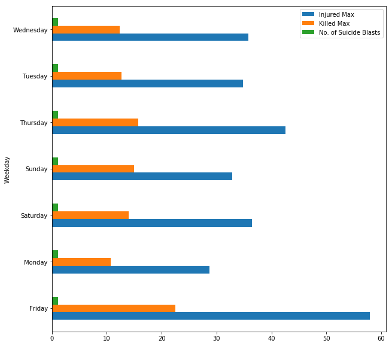

```python
pakistan_avg[['Injured Max', 'Killed Max', 'No. of Suicide Blasts']].plot(kind='barh', figsize=(10,10))
#show  summary of atacks that occured on each weekday.
```

```python
#the visualization above might look nice but it can be misleading and not true because the data still need to be clean.
#as we mention before there's missing values... (a lot of missing values)
#if we look at the missing values, it shows that every column in this df has missing values
#but we do not know how consistent are the missing values (if the values missing are from the same rows)
```

one thing we can do here without even looking at what is missing where... is; we can just drop the rows that have missing data in each column. Because if a row is missing values in every column then we can simply consider that row as never existed or unless we have another copy of the same df where we can sort of reference the index or something

```python
#so we gonna go ahead and delete those empty rows
pakistan.dropna(how='all', inplace=True)

#it looks like we have done a great job we can see some columns if 0 missing values now
#the original shape of our df was (483, 28) now we are left with (445, 28). we roughly lost 7.8% our data not good

pakistan.isnull().sum()
```

```
S#                           0
Date                         0
Islamic Date               134
Blast Day Type              10
Holiday Type               376
Time                       183
City                         0
Latitude                     0
Longitude                    0
Province                     0
Location                     3
Location Category           14
Location Sensitivity        17
Open/Closed Space           16
Influencing Event/Event    292
Target Type                 13
Targeted Sect if any        33
Killed Min                 145
Killed Max                  14
Injured Min                125
Injured Max                 27
No. of Suicide Blasts       66
Explosive Weight (max)     290
Hospital Names             173
Temperature(C)               1
Temperature(F)               1
date_parsed                  0
Weekday                      0
dtype: int64
```

```python
#I'm gonna make a copy of this df so that at least i have a reset point in case i mess up with the data
#and since the number of the column that we are interested in has lest than 5% of the total df
#im going to take responsability and drop any row where those values are missing
paki_copy=pakistan.dropna(subset=['Injured Max','Killed Max'],how='any')
```

```python
#one way we can fix the no. of suicide blasts column is by auto filling them with average suicide blasts.
#because if we look at the number of people killed, there isn't a pattern that we can use, it just random
#whether there was 1.0, 2.0 or 3 suicide blasts, the number are just shuffling
#we can look for other columns maybe the attack was not a suicide attack. the only column we can
#really think of is the explosive weight but it also doen't really help in this case
#so the missing is completely at random
```

```python
paki_copy.loc[paki_copy['No. of Suicide Blasts'].isnull(),['Killed Max','No. of Suicide Blasts', 'Explosive Weight (max)']]
```

|  | Killed Max | No. of Suicide Blasts | Explosive Weight (max) |
| --- | --- | --- | --- |
| 401 | 2.0 | NaN | NaN |
| 441 | 3.0 | NaN | NaN |
| 437 | 21.0 | NaN | NaN |
| 436 | 62.0 | NaN | NaN |
| 416 | 0.0 | NaN | NaN |
| 376 | 12.0 | NaN | NaN |
| 408 | 2.0 | NaN | NaN |
| 405 | 0.0 | NaN | 5kg |
| 421 | 11.0 | NaN | 14kg |
| 392 | 15.0 | NaN | 6-7Kg |
| 387 | 3.0 | NaN | 6kg |
| 426 | 28.0 | NaN | NaN |
| 179 | 2.0 | NaN | NaN |
| 419 | 3.0 | NaN | 60kg |
| 417 | 4.0 | NaN | 6kg |
| 332 | 3.0 | NaN | NaN |
| 420 | 11.0 | NaN | NaN |
| 410 | 2.0 | NaN | NaN |
| 154 | 1.0 | NaN | NaN |
| 412 | 13.0 | NaN | NaN |
| 394 | 8.0 | NaN | NaN |
| 381 | 10.0 | NaN | 6kg |
| 403 | 0.0 | NaN | NaN |
| 385 | 2.0 | NaN | NaN |
| 389 | 14.0 | NaN | NaN |
| 430 | 5.0 | NaN | NaN |
| 386 | 7.0 | NaN | NaN |
| 435 | 2.0 | NaN | NaN |
| 423 | 5.0 | NaN | 10kg |
| 393 | 30.0 | NaN | NaN |
| 440 | 17.0 | NaN | NaN |
| 425 | 30.0 | NaN | NaN |
| 433 | 55.0 | NaN | 15KG |
| 144 | 37.0 | NaN | NaN |
| 207 | 18.0 | NaN | NaN |
| 411 | 3.0 | NaN | 20-25kg |
| 413 | 6.0 | NaN | NaN |
| 418 | 13.0 | NaN | 25-30kg |
| 422 | 4.0 | NaN | NaN |
| 427 | 2.0 | NaN | NaN |
| 432 | 3.0 | NaN | NaN |
| 404 | 7.0 | NaN | NaN |
| 434 | 148.0 | NaN | NaN |
| 415 | 9.0 | NaN | 5Kg |
| 428 | 3.0 | NaN | NaN |
| 383 | 12.0 | NaN | NaN |
| 391 | 34.0 | NaN | 7-8kg |
| 382 | 1.0 | NaN | NaN |
| 409 | 3.0 | NaN | NaN |
| 407 | 5.0 | NaN | NaN |
| 414 | 3.0 | NaN | NaN |
| 384 | 3.0 | NaN | NaN |
| 429 | 5.0 | NaN | 45KG |
| 424 | 5.0 | NaN | 2kg |
| 439 | 5.0 | NaN | NaN |
| 431 | 7.0 | NaN | NaN |
| 442 | 3.0 | NaN | NaN |
| 402 | 9.0 | NaN | NaN |

```python
paki_copy.loc[paki_copy['No. of Suicide Blasts']>1,['Killed Max','No. of Suicide Blasts', 'Explosive Weight (max)']]
```

|  | Killed Max | No. of Suicide Blasts | Explosive Weight (max) |
| --- | --- | --- | --- |
| 396 | 50.0 | 2.0 | NaN |
| 250 | 57.0 | 2.0 | 12 kg |
| 343 | 4.0 | 3.0 | NaN |
| 265 | 80.0 | 2.0 | NaN |
| 58 | 7.0 | 2.0 | NaN |
| 311 | 95.0 | 2.0 | 16-20kg |
| 374 | 4.0 | 2.0 | 6kg |
| 255 | 56.0 | 3.0 | NaN |
| 284 | 50.0 | 2.0 | NaN |
| 226 | 45.0 | 2.0 | NaN |
| 339 | 8.0 | 3.0 | NaN |
| 257 | 44.0 | 2.0 | 12 Kg |
| 247 | 4.0 | 2.0 | 250Kg |
| 245 | 1.0 | 2.0 | 5Kg |
| 398 | 81.0 | 2.0 | NaN |
| 196 | 1.0 | 2.0 | NaN |
| 307 | 50.0 | 2.0 | NaN |
| 0 | 15.0 | 2.0 | NaN |
| 243 | 15.0 | 2.0 | NaN |
| 395 | 9.0 | 2.0 | NaN |
| 276 | 10.0 | 2.0 | 6 kg |
| 113 | 100.0 | 2.0 | NaN |
| 264 | 42.0 | 2.0 | 20 kg |
| 68 | 145.0 | 2.0 | NaN |
| 5 | 18.0 | 2.0 | 30kg in each car |
| 78 | 12.0 | 2.0 | NaN |
| 368 | 93.0 | 2.0 | NaN |
| 99 | 8.0 | 2.0 | NaN |
| 209 | 6.0 | 2.0 | 16 Kg |
| 271 | 43.0 | 3.0 | NaN |
| 328 | 28.0 | 2.0 | 100kg |
| 10 | 3.0 | 2.0 | NaN |

```python
#let's go ahead and fill those missing values with  the averege of it columns
paki_copy['No. of Suicide Blasts'].fillna(round(paki_copy['No. of Suicide Blasts'].mean()), inplace=True)

print('GREAT STUFF')
paki_copy['No. of Suicide Blasts'].isnull().sum()
```

```
GREAT STUFF
```

```
0
```

now that the columns that we need are clean, we can show summary of atacks that occured on each weekdays by grouping the data fisrt

```python
#WE're kinda overiding the first group_by_weekday object
pakistan_by_weekday = paki_copy.groupby(by=['Weekday']).sum()
pakistan_by_weekday.head()
```

| Weekday | S# | Latitude | Longitude | Killed Min | Killed Max | Injured Min | Injured Max | No. of Suicide Blasts | Temperature(C) | Temperature(F) |
| --- | --- | --- | --- | --- | --- | --- | --- | --- | --- | --- |
| Friday | 16194.0 | 2471.1705 | 5338.1025 | 1270.0 | 1748.0 | 2593.0 | 4399.0 | 82.0 | 1551.960 | 5193.528 |
| Monday | 15540.0 | 2309.9434 | 4995.6393 | 464.0 | 770.0 | 1235.0 | 2072.0 | 75.0 | 1368.725 | 4703.705 |
| Saturday | 11440.0 | 1862.6034 | 3982.9438 | 550.0 | 849.0 | 1348.0 | 2108.0 | 61.0 | 1114.420 | 3797.956 |
| Sunday | 9864.0 | 1512.6674 | 3275.0475 | 550.0 | 689.0 | 1015.0 | 1513.0 | 50.0 | 1022.650 | 3312.770 |
| Thursday | 15958.0 | 2300.3675 | 5084.2769 | 825.0 | 1156.0 | 1582.0 | 3155.0 | 81.0 | 1539.400 | 5074.920 |

FROM HERE WE CAN DECIDE DEPENDING ON WHAT WE ARE TRYING TO PROVE OR WHAT THE CLIENT WANT TO SEE. WE CAN SAY OK WE CAN LEAVE OUT THE minimum killed and injured COLUMNS BECAUSE THE MISSING VALUES ARE MORETHAN A QUARTER OF THE DF, AND FIX THE REMAINING COLUMNS. BUT IF THE CLIENT NEED TO SEE EVERYTHING... WELL NOTHING IS IMPOSSIBLE.

BUT THE LAST TIME I CHECK, MY CLIENT WAS THIS COMPULSORY TASK, AND THE REQUIREMENTS WAS SIMPLY JUST TO DO WHAT I JUST DID. SO WE'RE GOOD.

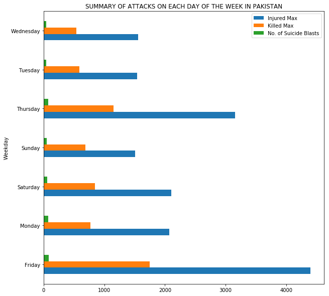

```python
pakistan_by_weekday[['Injured Max', 'Killed Max', 'No. of Suicide Blasts']].plot(kind='barh', figsize=(10,10))
plt.title('SUMMARY OF ATTACKS ON EACH DAY OF THE WEEK IN PAKISTAN')
#show  summary of atacks that occured on each weekdays.
```

```python
# Do a summary on the nature of attacks as grouped by the provinces.

# Be sure to understand that this yasl would need a lot of data cleaning and visualizations.
```

```python
#OK, SO WE KNOW THAT WE HAVE A HALF CLEAN DF AS paki_copy
#let's look at the columns and see whick columns will be needed to
#do the summary on the nature of attacks.
paki_copy.columns
```

```
Index(['S#', 'Date', 'Islamic Date', 'Blast Day Type', 'Holiday Type', 'Time',
       'City', 'Latitude', 'Longitude', 'Province', 'Location',
       'Location Category', 'Location Sensitivity', 'Open/Closed Space',
       'Influencing Event/Event', 'Target Type', 'Targeted Sect if any',
       'Killed Min', 'Killed Max', 'Injured Min', 'Injured Max',
       'No. of Suicide Blasts', 'Explosive Weight (max)', 'Hospital Names',
       'Temperature(C)', 'Temperature(F)', 'date_parsed', 'Weekday'],
      dtype='object')
```